# A 2023 EDA report on Sustainability Development Goals

Sukanya Lahkar

04-12-2023

**1. Introduction**

Everything around us has been constantly changing at a very fast rate. The world, as we once knew it, isn’t the same. Today the rate of population is very high in comparison to the available amount of resources around us. As such, it has become very important to focus on ways to get the most out of the available resources in the right way, without compromising on the essential needs for the future. This has been made possible by creating ‘Sustainable Development’ goals - an approach that the United Nations adopted in the year 2015, to focus on reducing and resolving environmental, economic and social issues.

The Sustainable Development Report dataset for the year 2023 has been considered here. For the 17 different sustainability goals put forward by the United Nations, and these goals intended to be achieved by 2030, it would be quite fascinating to observe which countries or regions are leading today and which of those are lagging behind; whether the sustainable goals pertaining to different areas of environment, social and economy are related to one another; which goals are the ones that have been achieved by almost all the countries; how the different regions are performing, overall..the list of questions about this dataset can be never-ending!

With the world struggling to survive through so many major issues like depleting resources, injustice, wars, inadequate availability of daily necessities, pandemics, ever-growing population, etc., it would be quite interesting to explore this dataset to get to know, for a start, at which stage the world currently is, with respect to, making positive changes or reducing the damages that has been caused economically, socially and environmentally.

**2. Understanding the Data**

Published on the eve of the 2023 Paris summit for a new Global Impact, the dataset on “Sustainability Development Goals”, is available for download on [Kaggle](https://www.kaggle.com/datasets/sazidthe1/sustainable-development-report/) and is annually updated.

The core data on sustainable development in the dataset, which comes from the UN Statistics Division’s Open SDG Data Hub, has been provided by the [SDG Transformation Center](https://sdgtransformationcenter.org/reports/sustainable-development-report-2023/). The SDG data in the data hub is collected annually from regional and national-level organizations of various countries. The collected data is obtained from different types of studies - cohort, case-control, cross-sectional, qualitative, to name a few. It is then compiled and verified globally by custodian agencies of the United Nations(UN). For example, UN custodian agencies like the World Health Organization(WHO) and United Nations Children’s Fund(UNICEF) compile and verify the data related to waste water, drinking water, sanitation, hygiene at the global level.

© Citation: Jeffrey D. Sachs, Guillaume Lafortune, Grayson Fuller and Eamon Drumm, 2023.

Authors: Sachs, J.D., Lafortune, G., Fuller, G., Drumm, E. (2023). Implementing the SDG Stimulus. Sustainable Development Report 2023. Dublin: Dublin University Press, 2023. 10.25546/102924

It is to be noted that the UN DESA in collaboration with the entire UN Statistical System, along with international and regional agencies, comes up with an annual SDG report that contain interactive dashboards and a user-friendly interface. The report, in summary, showcases the existing gaps currently that are not helping to achieve the targets of the SDG goals set, urging countries and their people to double their efforts, and portraying that success toward achieving these goals is not impossible, thanks to present day’s available technologies, resources and knowledge. The report can be found [here](https://unstats.un.org/sdgs/report/2023/).

```r
# Import Data
indata <- read.csv("sustainable_development_report_2023.csv")
# Check if data import was as expected
dim(indata)
```

```
## [1] 166  21
```

```r
head(indata, 2)
```

|  | country_code | country | region | overall_score | goal_1_score | goal_2_score | goal_3_score | goal_4_score | goal_5_score | goal_6_score | goal_7_score | goal_8_score | goal_9_score | goal_10_score | goal_11_score | goal_12_score | goal_13_score | goal_14_score | goal_15_score | goal_16_score | goal_17_score |
| --- | --- | --- | --- | --- | --- | --- | --- | --- | --- | --- | --- | --- | --- | --- | --- | --- | --- | --- | --- | --- | --- |
| 1 | FIN | Finland | OECD | 86.76059 | 99.5750 | 60.88675 | 95.38638 | 97.16933 | 92.11125 | 94.3276 | 93.0135 | 86.78900 | 95.99571 | 98.4685 | 91.23375 | 60.05957 | 68.79367 | 87.92800 | 85.0700 | 92.52109 | 75.60100 |
| 2 | SWE | Sweden | OECD | 85.98140 | 98.8885 | 63.07413 | 96.90400 | 99.76167 | 91.44025 | 95.0576 | 97.9735 | 84.96643 | 97.58629 | 94.9650 | 90.38925 | 56.83057 | 70.03100 | 69.34867 | 80.1882 | 88.50845 | 85.77025 |

The dataset contains 166 records with 21 variables. Each record contains information about sustainability achieved, related to a country. Every country is represented by a ‘country code’ and ‘country’ variable respectively. Each of these countries have been categorized into a particular region, that is being represented by the ‘region’ variable. The rest of the 18 numerical variables represent the 17 Sustainability Development Goals, set forth by the UN, that tells us how much percentage of those goals have been achieved by the 166 countries across the globe and the overall average score variable shows the total progress of each country towards achieving all of these goals combined. Every goal is scored between 0 and 100, based on different indicators(not part of the dataset) set forth by the UN. The 17 goals of sustainability development for each country, that are the 17 variables in our dataset, are :

Goal 1 - Eradicating all forms of poverty.  
Goal 2 - End hunger, promote sustainable agricultural methods, non-prevalence of malnutrition and obesity.  
Goal 3 - Promote healthy lifestyle and well-being.  
Goal 4 - Ensure quality education.  
Goal 5 - Empowering all women and girls and eradicating gender inequality.  
Goal 6 - Ensuring availability of clean water and hygienic sanitation.  
Goal 7 - Access to sustainable and affordable modes of energy.  
Goal 8 - Economic growth.  
Goal 9 - Industry, Innovation and Infrastructure.  
Goal 10 - Reduce inequality within and among countries.  
Goal 11 - Safe and sustainable cities and communities.  
Goal 12 - Responsible Consumption and Production.  
Goal 13 - Action toward climate change and its impacts.  
Goal 14 - Sustainable use of oceans, seas and marine resources.  
Goal 15 - Protect wildlife and forests, reverse deforestation, halt biodiversity loss.  
Goal 16 - Promote peace, justice and strong institutions.  
Goal 17 - Global partnership for sustainable development.

We will study all of these variables as that will help in answering most of the questions about this dataset.

Let’s first check the quality of the data.

```r
#Sort data in ascending order of country names
sdata <- indata[order(indata$country),]

#Find the count of duplicate rows
sum(duplicated(sdata))
```

```
## [1] 0
```

```r
#Find missing values
colSums(is.na(sdata))
```

```
##  country_code       country        region overall_score  goal_1_score
##             0             0             0             0            15
##  goal_2_score  goal_3_score  goal_4_score  goal_5_score  goal_6_score
##             0             0             0             0             0
##  goal_7_score  goal_8_score  goal_9_score goal_10_score goal_11_score
##             0             0             0            17             0
## goal_12_score goal_13_score goal_14_score goal_15_score goal_16_score
##             0             0            40             0             0
## goal_17_score
##             0
```

```r
#Replace missing values with zero
sdrdata <- sdata
sdrdata <- sdrdata %>% replace(is.na(.), 0)
colSums(is.na(sdrdata))
```

```
##  country_code       country        region overall_score  goal_1_score
##             0             0             0             0             0
##  goal_2_score  goal_3_score  goal_4_score  goal_5_score  goal_6_score
##             0             0             0             0             0
##  goal_7_score  goal_8_score  goal_9_score goal_10_score goal_11_score
##             0             0             0             0             0
## goal_12_score goal_13_score goal_14_score goal_15_score goal_16_score
##             0             0             0             0             0
## goal_17_score
##             0
```

```r
#Summary of data
summary(sdrdata)
```

```
##  country_code         country             region          overall_score
##  Length:166         Length:166         Length:166         Min.   :38.68
##  Class :character   Class :character   Class :character   1st Qu.:60.55
##  Mode  :character   Mode  :character   Mode  :character   Median :69.38
##                                                           Mean   :67.55
##                                                           3rd Qu.:74.95
##                                                           Max.   :86.76
##   goal_1_score     goal_2_score    goal_3_score    goal_4_score
##  Min.   :  0.00   Min.   :19.81   Min.   :12.95   Min.   : 1.232
##  1st Qu.: 38.09   1st Qu.:54.01   1st Qu.:51.86   1st Qu.:61.418
##  Median : 88.04   Median :61.03   Median :75.44   Median :84.773
##  Mean   : 68.44   Mean   :59.80   Mean   :69.69   Mean   :76.513
##  3rd Qu.: 98.89   3rd Qu.:67.26   3rd Qu.:85.52   3rd Qu.:95.644
##  Max.   :100.00   Max.   :83.40   Max.   :97.12   Max.   :99.762
##   goal_5_score    goal_6_score    goal_7_score     goal_8_score
##  Min.   :13.05   Min.   :32.60   Min.   : 8.697   Min.   :39.53
##  1st Qu.:51.05   1st Qu.:55.24   1st Qu.:47.521   1st Qu.:66.43
##  Median :65.87   Median :67.88   Median :68.613   Median :73.16
##  Mean   :63.29   Mean   :66.71   Mean   :61.414   Mean   :71.95
##  3rd Qu.:76.14   3rd Qu.:76.04   3rd Qu.:74.364   3rd Qu.:79.63
##  Max.   :94.02   Max.   :95.06   Max.   :99.551   Max.   :93.38
##   goal_9_score    goal_10_score    goal_11_score   goal_12_score
##  Min.   : 1.655   Min.   :  0.00   Min.   :13.83   Min.   :37.73
##  1st Qu.:30.206   1st Qu.: 27.74   1st Qu.:59.97   1st Qu.:68.59
##  Median :48.169   Median : 63.10   Median :76.85   Median :84.57
##  Mean   :51.601   Mean   : 56.47   Mean   :72.18   Mean   :79.78
##  3rd Qu.:74.713   3rd Qu.: 83.60   3rd Qu.:86.50   3rd Qu.:94.08
##  Max.   :99.129   Max.   :100.00   Max.   :99.86   Max.   :98.81
##  goal_13_score   goal_14_score   goal_15_score   goal_16_score
##  Min.   : 0.00   Min.   : 0.00   Min.   :26.48   Min.   :29.44
##  1st Qu.:72.54   1st Qu.:38.92   1st Qu.:56.61   1st Qu.:49.03
##  Median :90.90   Median :61.83   Median :66.30   Median :60.91
##  Mean   :82.12   Mean   :49.71   Mean   :66.64   Mean   :61.55
##  3rd Qu.:96.71   3rd Qu.:71.19   3rd Qu.:76.58   3rd Qu.:73.72
##  Max.   :99.93   Max.   :90.39   Max.   :97.85   Max.   :93.84
##  goal_17_score
##  Min.   :29.35
##  1st Qu.:50.85
##  Median :60.80
##  Mean   :60.95
##  3rd Qu.:71.65
##  Max.   :94.03
```

With the data quality check complete for the data, let’s now explore the dataset through some visualizations that can be a starting point in answering some of the questions about this dataset.

**3. Exploratory Data Analysis**

To represent the summary statistics, the box-plot visualization has been considered to understand the overall SDG scores of different countries pertaining to the respective regions.

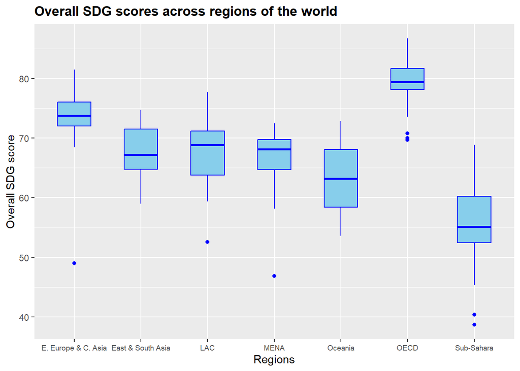

```r
sdrdata4<-select(sdrdata, region, overall_score)

#plotting boxplots
ggplot(sdrdata4, aes(x=region, y=overall_score))+geom_boxplot(fill = "skyblue", color = "blue", width = 0.5)+xlab("Regions")+ylab("Overall SDG score")+ggtitle ("Overall SDG scores across regions of the world") + theme(plot.title = element_text(face = "bold"))+ theme(axis.text.x = element_text(size = 7))
```

It can be observed that 50% of the countries belonging to Eastern Europe and Central Asia region have overall SDG scores ranging approximately between 73-76, 50% of the countries in the East and South Asia region have scores ranging between 65-72, 50% of the countries in the Sub-Sahara region have overall SDG scores ranging between 53-60 and so on. For the OECD region, 50% of the countries have scores ranging between 78-82, 25% of the countries have scores greater than 82, while the remaining 25% have scores below 78. Similar interpretations can be concluded by observing the boxplots of the other regions. There are also outliers for five of the regions. In reality, these outliers/countries need to be examined properly to understand the various reasons as to why they are not performing well in comparison to the other countries belonging to the same region.

Let’s now use horizontal bar charts to figure out from the dataset, among the different regions, which countries are currently leading and which are still lagging behind. Here, the focus will be on countries whose overall SDG scores are greater than 85 or below 50. Why? Since the timeline to achieve the goals is quite near, hence if we filter the countries based on a comparatively high and low overall SDG score, it would make more sense to understand which countries might reach the end goal sooner and which of them won’t.

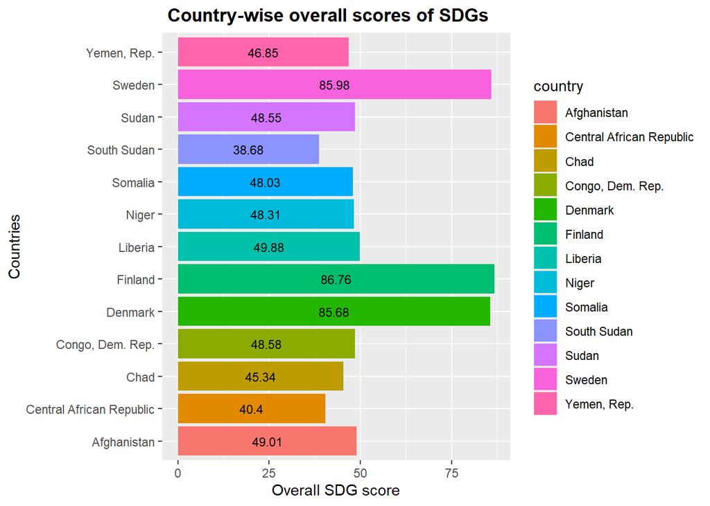

```r
sdrdata2<-select(sdrdata,country,overall_score)
sdr_data2 <- sdrdata2 %>% filter( overall_score > 85 | overall_score<50 )

sdr_data2$overall_score <- round(sdr_data2$overall_score,2)

#plotting horizontal bar charts
ggplot(sdr_data2,aes(x=country, y=overall_score, fill=country)) + geom_bar(stat="identity") + coord_flip() + labs(y ="Overall SDG score", x = "Countries") + ggtitle(" Country-wise overall scores of SDGs") + theme(plot.title = element_text(face = "bold")) + geom_text(aes(label = overall_score),
            position = position_stack(vjust = 0.5), size = 3)
```

So the above visualization has made it quite clear that Finland is on currently on top, while South Sudan is on the bottom of the list of countries which are targeting to achieve the sustainability development goals by 2030. But it is not yet known which goals are contributing to the difference between the overall scores of these two countries? The following visualization helps to understand the answer to this question. The focus will be only on the Economic goals for now, but this visualization can also be extended to get similar information about the Social and Environmental goals as well.

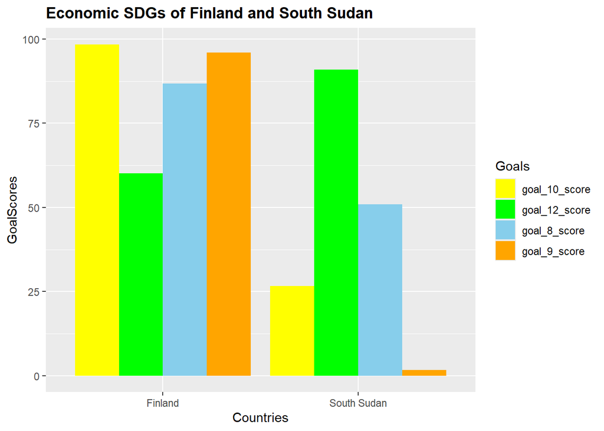

```r
sdrdata3<-select(sdrdata,country,goal_8_score,goal_9_score,goal_10_score,goal_12_score)
sdr_data3 <- sdrdata3 %>% filter( country %in% 'Finland' | country %in% 'South Sudan')

data_long <- gather(sdr_data3, key = "Goals", value="value", -country)

#plotting column charts
column_chart <- ggplot(data_long, aes(x=country, y=value, fill=Goals)) + geom_bar(stat = "identity", position = "dodge") + ggtitle("Economic SDGs of Finland and South Sudan")+xlab("Countries")+ylab("GoalScores")+scale_fill_manual(values = c("goal_8_score"="skyblue","goal_9_score"="orange","goal_10_score"="yellow","goal_12_score"="green"))+ theme(plot.title = element_text(face = "bold"))

print(column_chart)
```

From the figure above, the difference between the two countries in terms of the economic goals achieved is quite contrasting. The score for Goal 10 (concerted efforts to address the root causes of wage disparities and access to resources both within-and between-country inequality) is quite close to 100 for Finland, while for South Sudan, it is only around 27. A similar statement can be made about the Goal 8 scores (promote sustained, inclusive and sustainable economic growth, full and productive employment and decent work for all) for both the countries, with Finland scoring around 87 while South Sudan scoring around 50. The major striking difference comes with the Goal 9 scores (build resilient infrastructure, promote sustainable industrialization and foster innovation), with Finland scoring very high, but South Sudan showing very limited progress of around 2%. The only score where South Sudan scores more than Finland surprisingly is for Goal 12 (sustainable consumption and production patterns). But there may be a catch here. Finland, being a developed country, over-consume the natural resources and use modern-day products that are probably produced not-so responsibly. In the case of South Sudan, with the country still being under-developed, a major percentage of the natural resources are probably left untouched and modern-day products are not used to a large extent. Overall, by looking at this chart, it is very clear for both the respective countries, which goals they should work upon to increase their SDG scores and achieve sustainable development by 2030.

**4. Inference from the Data**

*4.1. Principal Component Analysis*

As there are 17 variables in our dataset, let’s perform Principal Component Analysis (PCA) to understand if we are able to retain essential information and understand the data patterns. This means, we now try to check if a country’s current SDG progress information can be identified through a smaller set of variables. Although the princomp() function can be directly used for PCA, but below is the r code for a step-by-step process for PCA. We first normalize the dataset so that all the variables are expressed on the same scale. This is to make sure all the variables contribute equally to the results. The covariance matrix is then calculated based on the scaled data. Eigen analysis is also conducted.

```r
#Include only numeric variables.
PCA_sdrdata<-subset(sdrdata, select = -c(country_code,country,region,overall_score))
scaled.data <- scale (PCA_sdrdata)
s <- cov(scaled.data)
s %>% round(2)
```

[output not shown]

```r
s.eigen <- eigen(s) #Eigen analysis
s.eigen$values %>% round(3)
```

```
##  [1] 8.927 1.458 1.131 1.050 0.853 0.808 0.507 0.430 0.360 0.309 0.247 0.237
## [13] 0.198 0.180 0.132 0.088 0.086
```

The eigen values add up to the number of variables,i.e., 17, due to normalization. Based on the proportion of variances and cumulative proportion calculated in the below code, it is observed that 6 principal components (PCs) account for more than 80% of the variance in the 17 variables.This means that for the SDG dataset, in order to understand any country’s progress, the six PCs will explain 83% of the variation in the data.

```r
sum(s.eigen$values)
```

```
## [1] 17
```

```r
s.eigen.prop <- s.eigen$values/sum(s.eigen$values) #Proportion of variances
s.eigen.prop %>% round(3)
```

```
##  [1] 0.525 0.086 0.067 0.062 0.050 0.048 0.030 0.025 0.021 0.018 0.015 0.014
## [13] 0.012 0.011 0.008 0.005 0.005
```

```r
cumsum(s.eigen.prop) #Cumulative proportion
```

```
##  [1] 0.5251300 0.6109138 0.6774696 0.7392102 0.7893622 0.8369014 0.8667061
##  [8] 0.8920256 0.9131880 0.9313484 0.9458933 0.9598285 0.9714495 0.9820261
## [15] 0.9897725 0.9949491 1.0000000
```

```r
loadings <- round(s.eigen$vectors[,1:6], digits = 3)
rownames(loadings) <- colnames(PCA_sdrdata)
colnames(loadings) <- c("PC1", "PC2", "PC3","PC4","PC5","PC6")
loadings
```

```
##                  PC1    PC2    PC3    PC4    PC5    PC6
## goal_1_score  -0.218  0.360  0.284 -0.134  0.216 -0.083
## goal_2_score  -0.206  0.018  0.287  0.234 -0.116  0.618
## goal_3_score  -0.314 -0.099  0.039 -0.036  0.081 -0.046
## goal_4_score  -0.289 -0.075  0.191  0.054  0.037 -0.032
## goal_5_score  -0.240  0.001 -0.114  0.415 -0.161  0.035
## goal_6_score  -0.287  0.147  0.123  0.056 -0.079  0.003
## goal_7_score  -0.285 -0.057  0.188  0.045  0.013 -0.201
## goal_8_score  -0.256  0.054  0.024  0.013 -0.128  0.372
## goal_9_score  -0.306 -0.096 -0.053 -0.149  0.075  0.098
## goal_10_score -0.124  0.539 -0.030 -0.409  0.407  0.073
## goal_11_score -0.284 -0.090  0.075  0.203  0.065 -0.147
## goal_12_score  0.275  0.193  0.378  0.169 -0.066  0.014
## goal_13_score  0.206  0.373  0.458  0.168 -0.154 -0.110
## goal_14_score -0.062 -0.285  0.363 -0.651 -0.507 -0.023
## goal_15_score -0.062  0.492 -0.444 -0.076 -0.589  0.106
## goal_16_score -0.289  0.027 -0.208 -0.074  0.042 -0.112
## goal_17_score -0.204  0.136  0.031  0.152 -0.272 -0.596
```

It can be inferred from the output that PC1 is associated with high score for goal 12(Responsible Consumption and Production) as well as low score for goal 3(Promote healthy lifestyle and well-being). This means that PC1 distinguishes countries who are responsibly consuming and producing, from countries with poor lifestyle, and lack of well-being. The second principal component is associated with the good progress made by countries toward reducing inequality within and among other countries(goal 10). It also distinguishes countries who have been successfully able to preserve the well-being of wildlife and forests and halt biodiversity loss(goal 15) ,from countries who have not made any significant improvement towards responsibly utilizing the oceans, seas and marine resources(goal 14). Similar interpretations can further be made from the remaining 4 PCs to understand the data.

**5. Conclusion**

*5.1. Conclusion*

Through this report, the 2023 UN SDG goals were analysed. Exploratory data analysis and principal component analysis were performed that helped to understand the patterns and characteristics of the dataset. While Principal component analysis helped to answer that it is possible to understand almost 80% of this dataset by using a fewer number of dimensions; exploratory data analysis helped in answering our questions related to the current standings of countries, identifying those at the forefront and those falling behind; as well as how various regions are faring on the whole. In addition, these methods also helped to understand that despite one region making progress similar to another, it doesn’t necessarily imply that they are achieving the same goals.  
As the year 2023 comes to conclusion, it is imperative to reflect on the progress and challenges surrounding the Sustainable Development Goals (SDGs). These 17 goals have served as a beacon of hope and a roadmap for global collaboration to address the world’s most pressing issues. The pursuit of the SDGs requires an unwavering commitment from governments, businesses, communities, and individuals worldwide.

*5.2. Limitations*

This study has some limitations. The analysis performed is on the overall SDG data of the UN for the year 2023; the entire dataset of SDG since the year it started, should also be analysed for more thorough understanding of the progress being made by the different countries of the world. Another limitation is related to the fact that not all countries of every region provide their progress report to the UN. As such, whatever data is collected by the UN from the countries that report their progress, the analysis is carried out on that basis. Moreover, the SDG dataset will keep changing every year. Hence, the data analysis performed here should not be considered as the final progress report of the countries toward sustainable development.

*5.3. Future Scope*

Exploratory data analysis and inference of the entire dataset of the UN SDG goal, since the time it started, can be performed as part of future research work. Further, systematic review can also be done to understand the scoring system used to aggregate the indicators related to each of the 17 goals.

**6. References**

1. [United Nations - Department of Economic and Social Affairs](https://sdgs.un.org/goals)
2. [University of Washington - Applied Multivariate Statistics in R](https://uw.pressbooks.pub/appliedmultivariatestatistics/chapter/pca/)
3. [R for Data Science](https://r4ds.had.co.nz/index.html)
4. [An Introduction to R](https://cran.r-project.org/doc/manuals/r-release/R-intro.html)